# EX11: Boosted Regression Trees

Mia McReynolds, Eli Polzer, Matt Futia

13 March 2021

```r
# below is the recommended class root dir
path.root <- "~/University of Vermont/Classes/sdhmR/sdhmR-V2021.1"  # typical class root dir
  path.mod9 <- paste(path.root, "/data/module05.05-BRT", sep = "")
  path.figs <- paste(path.root, "/powerpoints/figures", sep = "")
  path.gis <- paste(path.root, "/data/gis_layers", sep = "")

# load libraries now if desired; loaded below when needed
  library(dplyr)
  library(ggplot2)
  library(tidyr) #load tidyverse first or they mask many fx's
  library(gbm)
  library(dismo)
  library(PresenceAbsence)
  library(sf)
```

## Question #1

- Import and explore data
  - **NOTE**: intent is not to reduce number of variables; that was completed in exercise #5. Rather, calculate simple descriptive statistics (mean, sd, n) and boxplots

```r
# load range-wide training data
load("~/University of Vermont/Classes/sdhmR/sdhmR-V2021.1/data/module02/tr_RANG.Rdata")

str(tr_RANG)
```

```
## 'data.frame':    5997 obs. of  11 variables:
##  $ FNETID    : num  9270 13732 22606 24072 40340 ...
##  $ RANG106   : num  0 0 0 0 0 0 0 0 0 0 ...
##  $ tr.wgs_x  : num  -111 -111 -111 -111 -111 ...
##  $ tr.wgs_y  : num  42.1 42.1 42 42 41.9 ...
##  $ etpt_5    : num  88 85 88 85 88 79 85 75 88 87 ...
##  $ mind_yr_av: num  -1105 -1008 -1141 -1025 -1153 ...
##  $ prad_sw_di: num  12163 12285 12079 12120 12181 ...
##  $ prec_w_hal: num  25.7 27.2 19.8 27.2 18.2 ...
##  $ rough_1k  : num  1.66 16.45 11.39 12.19 1.19 ...
##  $ tmax_s_hal: num  224 201 218 201 221 ...
##  $ topos     : num  -89.9 16.8 -46.7 22.7 -30.8 ...
```

```r
#pivot for ggplotting/summary
tr_RANG_long <- tr_RANG %>%
  pivot_longer(etpt_5:topos, names_to = "Variable", values_to = "Value")

tr_RANG_long %>% group_by(Variable) %>%
  summarise(n = n(),
            mean = mean(Value),
            sd = sd(Value),
            min = min(Value),
            max = max(Value))
```

```
## # A tibble: 7 x 6
##   Variable       n     mean     sd      min    max
##   <chr>      <int>    <dbl>  <dbl>    <dbl>  <dbl>
## 1 etpt_5      5997    91.6    7.30     0       99
## 2 mind_yr_av  5997 -1400.   323.   -2065.     153.
## 3 prad_sw_di  5997 10929.   684.    8070.   13026.
## 4 prec_w_hal  5997    26.1   13.1      6.33   130.
## 5 rough_1k    5997    17.3   15.7      0      130.
## 6 tmax_s_hal  5997   249.    38.5     87.8    368.
## 7 topos       5997     1.55  48.7   -209.     334
```

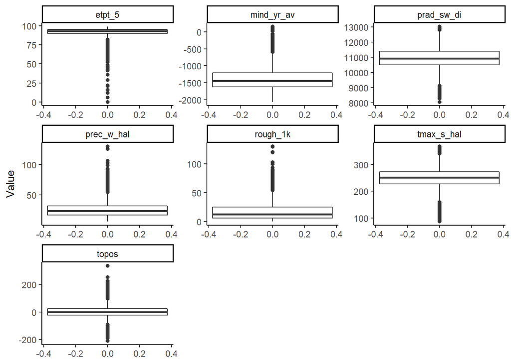

```r
#boxplot
ggplot(tr_RANG_long, aes(y=Value)) +
  geom_boxplot() +
  facet_wrap(~Variable, scales="free") +
  theme_classic()
```

Same code as EX 9.

## Question #2

- Construct a boosted regression tree (BRT) model using the presence:absence data
- Build plots of variable importance values

```r
# BRT model formulation. tr_RANG=dat1
  tr_RANG <- na.omit(tr_RANG) # remove NAs - BRT not picky but drop 'em anyway
  resp <- paste("as.factor(", colnames(tr_RANG[2]), ")", sep = "") # assign resp to col number
  n.col <- ncol(tr_RANG) # number of columns
  pred <- 5:n.col # assign predictors to column numbers
```

```
##
##
##  GBM STEP - version 2.9
##
## Performing cross-validation optimisation of a boosted regression tree model
## for RANG106 and using a family of bernoulli
## Using 5997 observations and 7 predictors
## creating 10 initial models of 50 trees
##
##  folds are stratified by prevalence
## total mean deviance =  1.273
## tolerance is fixed at  0.0013
## ntrees resid. dev.
## 50    1.0164
## now adding trees...
## 100   0.9875
## 150   0.9792
## 200   0.9762
## 250   0.9731
## 300   0.9714
## 350   0.971
## 400   0.9717
## 450   0.9715
## 500   0.9715
## 550   0.9719
## 600   0.9721
## 650   0.9716
## 700   0.972
## 750   0.9736
## 800   0.9747
## 850   0.9762
## 900   0.9773
## 950   0.9777
## 1000   0.9783
## 1050   0.98
```

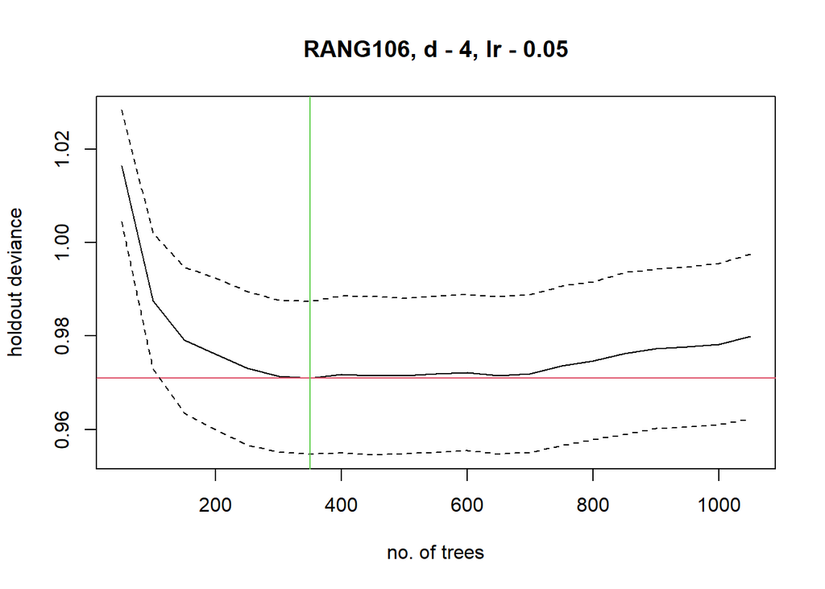

```
##
## mean total deviance = 1.273
## mean residual deviance = 0.857
##
## estimated cv deviance = 0.971 ; se = 0.016
##
## training data correlation = 0.607
## cv correlation =  0.505 ; se = 0.013
##
## training data AUC score = 0.867
## cv AUC score = 0.808 ; se = 0.007
##
## elapsed time -  0.02 minutes
```

```r
# BRT model - gbm.y = 2 now (response col). used ROT for LR and TC
  mod2.RANG.BRT <- gbm.step(data = tr_RANG, gbm.x = pred, gbm.y = 2, family = "bernoulli",
    tree.complexity = 4, learning.rate = 0.05, bag.fraction = 0.75, n.folds = 10,
    plot.main = TRUE, keep.fold.fit = TRUE)
```

No optimal solution with d=3 and lr=0.01. Need to play w/ the parameters… I’ll increase complexity to 4 (because sample size in the thousands), and increase LR to 0.05. Now it’s found an inflection point.

```r
# examine BRT output
  mod2.RANG.BRT$contributions # relative variable importance
```

```
##                   var   rel.inf
## tmax_s_hal tmax_s_hal 28.547856
## rough_1k     rough_1k 22.741492
## mind_yr_av mind_yr_av 15.664841
## prec_w_hal prec_w_hal 12.537037
## topos           topos  8.024667
## prad_sw_di prad_sw_di  6.518711
## etpt_5         etpt_5  5.965396
```

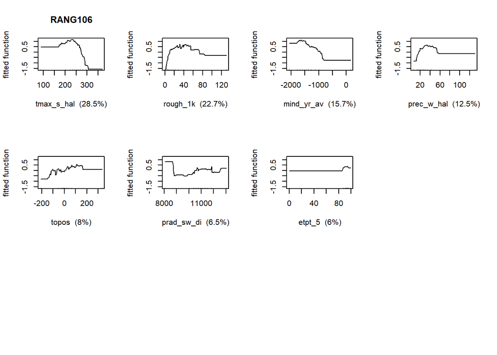

```r
# examine response:predictor plots
  par(mfrow = c(3, 4))
  gbm.plot(mod2.RANG.BRT, n.plots = 7) # response:predictor plots
```

```r
    #these are descriptive: importance of factors depending on preds
  par(mfrow = c(1, 1))
```

```r
# search for & examine interactions
  mod2.int <- gbm.interactions(mod2.RANG.BRT) # examine pairwise interactions
  mod2.int$rank.list # matrix of 5 top interactions
```

```
##   var1.index var1.names var2.index var2.names int.size
## 1          6 tmax_s_hal          2 mind_yr_av   156.81
## 2          6 tmax_s_hal          3 prad_sw_di    26.53
```

```r
  #mod2.int$interactions # NOT RUN: matrix all pairwise interactions
```

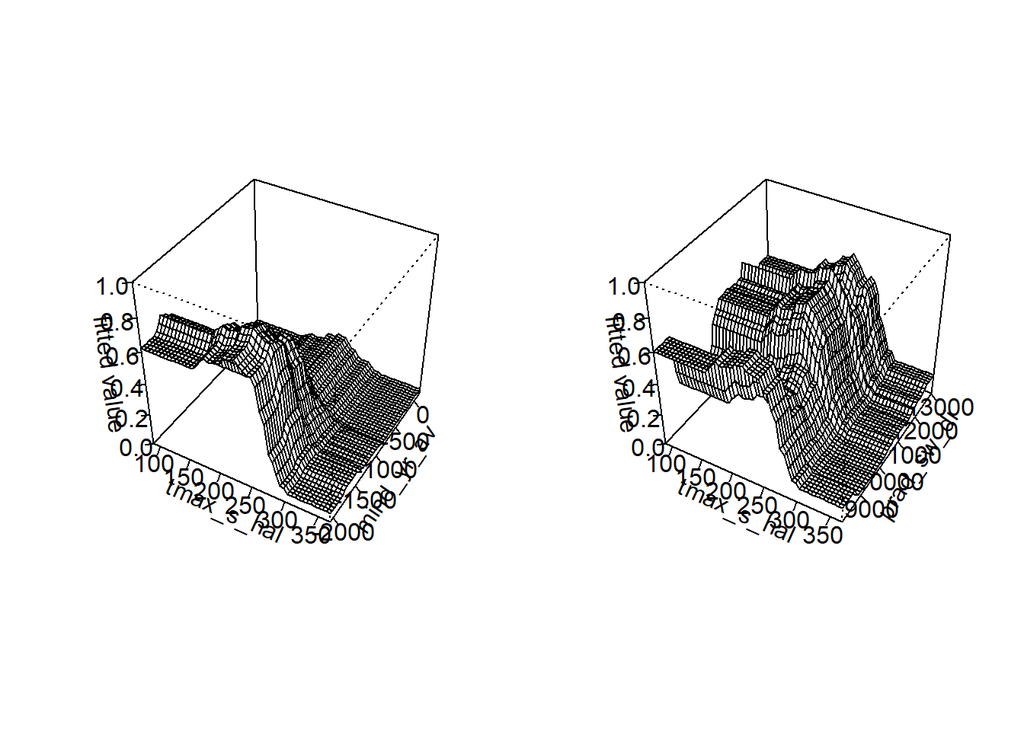

```r
# plot 2 top pairwise interactions
  par(mfrow = c(1, 2))
  gbm.perspec(mod2.RANG.BRT, mod2.int$rank.list[1, 1], mod2.int$rank.list[1, 3], theta = 30)
  gbm.perspec(mod2.RANG.BRT, mod2.int$rank.list[2, 1], mod2.int$rank.list[2, 3], theta = 30)
```

```r
  par(mfrow = c(1, 1))
```

## Question #3

- Calculate accuracy metrics (as in Module 3.2 and 3.3, Analytical Intermission) using:
  - Resubstitution approaches, and
  - A 10-fold cross–validation approach

```r
######## START ACCURACY CALCULATIONS, MODEL=BRT
# build testing dataframe using model predictions
  modl <- "mod2.RANG.BRT" # add var to keep track of model
  dat2 <- cbind(modl, tr_RANG[2], mod2.RANG.BRT$fitted, mod2.RANG.BRT$fold.fit) # build dataframe
  names(dat2)[3:4] <- c("pred", "cvpred") # rename vars
  head(dat2, 2) # just to see logit scale
```

```
##            modl RANG106       pred    cvpred
## 1 mod2.RANG.BRT       0 0.03165592 -3.124325
## 2 mod2.RANG.BRT       0 0.12526761 -2.166328
```

```r
  dat2$cvpred <- exp(dat2$cvpred)/(1 + exp(dat2$cvpred)) # convert from logit
  head(dat2, 5) # examine prediction dataframe
```

```
##            modl RANG106       pred     cvpred
## 1 mod2.RANG.BRT       0 0.03165592 0.04211497
## 2 mod2.RANG.BRT       0 0.12526761 0.10281525
## 3 mod2.RANG.BRT       0 0.32266052 0.36304907
## 4 mod2.RANG.BRT       0 0.13932434 0.10996894
## 5 mod2.RANG.BRT       0 0.01709354 0.01272749
```

```r
# determine best threshold using PresenceAbsence package
  mod.cut <- optimal.thresholds(dat2, opt.methods = c("ObsPrev")) # threshold=PREVALENCE
  mod.cut # examine
```

```
##    Method      pred    cvpred
## 1 ObsPrev 0.3333333 0.3333333
```

```r
# generate confusion matrix: resub and xfold
  mod2.cfmatR <- table(dat2[[2]], factor(as.numeric(dat2$pred >= mod.cut$pred)))
  mod2.cfmatX <- table(dat2[[2]], factor(as.numeric(dat2$cvpred >= mod.cut$cvpred)))
  mod2.cfmatR # examine
```

```
##
##        0    1
##   0 2811 1187
##   1  269 1730
```

```r
  mod2.cfmatX # examine
```

```
##
##        0    1
##   0 2699 1299
##   1  381 1618
```

```r
# calculate model accuracies with standard deviation=F
  mod2.acc <- presence.absence.accuracy(dat2, threshold = mod.cut$pred, st.dev = F)
  tss <- mod2.acc$sensitivity + mod2.acc$specificity - 1 # code TSS metric
  mod2.acc <- cbind(mod2.acc[1:7], tss) # bind all metrics
  mod2.acc[c(1, 4:5, 7:8)] # examine accuracies
```

```
##    model sensitivity specificity       AUC       tss
## 1   pred   0.8654327   0.7031016 0.8666412 0.5685343
## 2 cvpred   0.8094047   0.6750875 0.8081945 0.4844922
```

## Question #4

- Build 2 prediction maps:
  - A raw probability estimate for each cell in the modelling domain; and
  - A classified map based on the selected threshold from Question #3

```r
# boundaries for pretty maps (see Mod 2.5)
  setwd(path.gis)
  states <- st_read(dsn = ".", layer = "na_states_wgs") # import shapefile
# load raster stack
  load("~/University of Vermont/Classes/sdhmR/sdhmR-V2021.1/data/module02/rangeDOM.RData")
```

```r
#   ASSUME pred.dom is a raster stack per Module 4.1
setwd(path.mod9)

mod2.RANG.BRTprob <- predict(rangeDOM, mod2.RANG.BRT,
   n.trees = mod2.RANG.BRT$gbm.call$best.trees, type = "response",
   filename = "modFprob.RANG.BRT.img")
```

[output not shown]

```r
 mod2.RANG.BRTclas <- reclassify(mod2.RANG.BRTprob, c(0, mod.cut[[2]], 0,
   mod.cut[[2]], 1, 1))
```

[output not shown]

```r
 writeRaster(mod2.RANG.BRTclas, filename = "modFclas.RANG.BRT.img", format = "HFA")
```

[output not shown]

```r
 par(mfrow = c(1, 2))
  plot(mod2.RANG.BRTprob, legend = T, axes = T, main = "Probability Map") # plot clipped probability map
```

[output not shown]

```r
  plot(sf::st_geometry(states), add = T, lwd = 1.5) # add state boundaries
```

[output not shown]

```r
  plot(mod2.RANG.BRTclas, legend = F, axes = T, main = "Classification Map") # plot clipped classified map
```

[output not shown]

```r
  plot(sf::st_geometry(states), add = T, lwd = 1.5)  # add state boundaries
```

[output not shown]

```r
  par(mfrow = c(1, 1))

  BRTmaps_EX11 <- recordPlot()
```

## Question #5

- Save your data as R objects:
  - Accuracy metrics as a dataframe;
  - Classification threshold as a stand–alone scalar
  - Both prediction maps as **`.img`** format
- Save these R objects in a **`.RData`** file

These data will be used again in Module 10, Ensemble Models.

```r
setwd(path.mod9)

# Accuracy metrics as a dataframe
mod2.acc_EX11 <- mod2.acc

# Classification threshold as a stand--alone scalar
mod.cut.EX11 <- mod.cut[[2]]

#plot - also saved this manually
BRTmaps_EX11

save(mod2.acc_EX11, mod.cut.EX11, BRTmaps_EX11, file = "range.BRT_EX11.RData")
```